# Latent Factor Models

CP4285 Modern Recommendation Systems — Week 02

[figure not shown]

Scan for the slides  
soc-n.us/cp4285-t2610-w02

CP4285 Instruction Team

18 Aug 2026

# 01 Announcements and Context

##### Changelog

- **20 Aug 2026** — Refined content and classroom layouts for this release.
- **20 Aug 2026** — Added a linked Week 3 evaluation preview image and attribution.

WEEK 01 RECAP

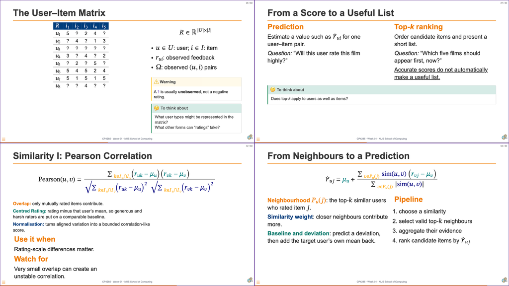

## Pre-Flight Survey · Metadata Summary

**Pre-flight survey · 26 submissions** — cohort signals

Computer Sciences**85%**22 of 26

Balance / practice**81%**lecture preference

IR knowledge**15%**4 of 26

Embeddings exposure**73%**19 of 26

DSA knowledge**92%**strong / decent

AI knowledge**100%**strong / decent

Industry cases**42%**10 of 24 responses

Retrieval / architectures**38%**9 of 24 responses

Build / deploy**33%**8 of 24 responses

Source: Canvas pre-flight survey. Programme selections were multi-select; learning-expectation themes were coded from 24 substantive answers.

## Pre-Flight Survey · Voices in the Room

**Open responses · representative anonymous phrases** — larger phrases indicate central themes, not frequency

“retrieval and ranking architectures”“more application based”“deployment and productionization”“TikTok / Instagram … real-world case studies”“YouTube and Spotify”“modern search alongside recommendation”“recommendation algorithms … real-world datasets”“end-to-end recommender … project”“Two Tower Model”“LLMs for recommendation … RAG or fine-tuning”“replicate papers”“create and deploy MCP server”“Heavy workload”“system design … production”“PyTorch … building and training”“latest research and progress”“form our own groups”“ethics … history and context”

● Systems and concepts● Building and deployment● Expectations and concerns

Source: Canvas pre-flight survey, anonymous open responses. Phrases are abbreviated from representative excerpts for slide readability.

## Essay 1: Micro Case Study: Designing a Production Recommender Surface

**Focus**  
One approved user-facing recommendation surface.

→

**Reason**  
One or two consequential Week 01–02 choices.

→

**Defend**  
Evidence, limits, and a substantive suit lens.

- ⚠️ (Short) **1,500 words** · Due **Mon, 24 Aug 2026, 23:59 SGT**.
- Use no more than **two external sources**; distinguish platform facts from your reasoned proposal.
- Feature a card-suit lens in the technical design, objective, constraint, or evaluation criterion.
- Include an AI-use declaration; AI may assist inquiry but you need to own the argument.

# 02 From Neighbours to Features to Latent Structure

Last Week Pre-Lecture Exercise

Look for Hidden Structure

Post a short, concrete response to this question; then reply constructively to one classmate.

Name one latent dimension that could explain several ratings—but is not an item metadata label.

Next week: turn this intuition into latent-factor representations of the user–item matrix.

Last Week Pre-Lecture Exercise · Canvas Voices

Latent dimensions students noticed 📶

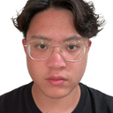

“Quality: Unlike a metadata like price or like count, you can't really quantify quality from the item itself.”

Reply“Quality is also subjective and can potentially be influenced by trendiness.”

Quality

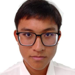

“Nostalgia. It's a property of the relationship between a user and an item which is driven by the user's personal history …”

Reply“Could it be modelled by grouping users into distinct age groups?”

Nostalgia

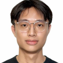

“Trust: It is not an item metadata label because it is an underlying, subjective perception that is not directly observable.”

Reply“The degree of trust cannot be readily quantified and it may vary widely …”

Trust

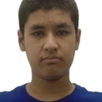

“One latent dimension is how emotionally provocative an item is? Some items naturally stimulate our excitement, motivation or pleasure …”

Reply“Psychological emotions are subjective … and it is tough to quantify.”

Emotion

## Three Routes to a Recommendation

Collaborative filtering  
(CF; last week)  
**Evidence**  
User–item interactions  
**Mechanism**  
Borrow from similar users or items  
**Watch**  
Thin local overlap can leave a neighbourhood silent.

|

Content-based filtering  
(CBF)  
**Evidence**  
Explicit item, user, or context features  
**IR mechanism**  
Encode and match genres, tags, and text  
**Watch**  
Feature coverage and encoding quality set the limit.

|

Latent-factor model  
(LFM)  
**Evidence**  
User–item interactions  
**Mechanism**  
Learn shared hidden coordinates from many interactions  
**Watch**  
A factor is a learned pattern, not a personal fact.

## Explicit Features Can Be Weighted

**Observed or stated fields** can enter a recommender score before any latent factors are learned.

### User / context fields

`student` · `Singapore` · `vegetarian`  
`weekday evening` · `budget: low`

Supplied, measured, or declared—not inferred from interaction patterns.

+

### Item fields

`cuisine: Thai` · `price: $$`
`genre: comedy` · `duration: 90 min`

Observed descriptions of a candidate item.

→

### Weighted score

$$\color{navy}{\operatorname{score}(u,i,c)}=\color{teal}{\mathbf{w}^{\top}}\color{orange}{\mathbf{x}(u,i,c)}$$

Vector *x* represents an item or a user. Use a similarity metric (Week 01) to define similarities.

**Features as explicit and implict**

An explicit field is an input we choose to represent. They can be fed as features to create latent factors later.

## Text Is One Possible Feature Source

Text can be an **item field**, **user field**, or **contextual need**.

### User / context text

`“animated family film”`  
`“a light comedy tonight”`

Profiles, reviews, queries, and session descriptions can express a need.

↔︎

### Movie item text

`Toy Story (1995)`  
`Animation · Children’s · Comedy`

Titles, genres, tags, synopses, and reviews can describe a candidate.

→

### Encoded feature

$$\color{teal}{\mathbf{x}_{\text{text}}}=\operatorname{encode}(\color{orange}{\text{text}})$$

Encoding maps words to coordinates for comparison or combination.

> **IR** matches text representations; the same encoding can furnish recommender features.

## A Bag of Words Is Sparse and Literal

text / term

animated

family

light

comedy

animation

children

need: animated family film

1

1

0

0

0

0

need: light comedy tonight

0

0

1

1

0

0

item: Toy Story (1995)

0

0

0

1

1

1

- One coordinate per vocabulary term; most coordinates are zero.
- The second need shares `comedy`; the first shares no exact coordinate with the listed movie genres.
- `animated` and `animation`, and `family` and `children`, remain separate until another mechanism relates them.

## TF and IDF Signal Different Things

### TF: local evidence

$$\color{orange}{\operatorname{tf}(t,d)}=\text{count of term }t\text{ in document }d$$

Repeated occurrence can strengthen a term’s contribution **within one document**.

### IDF: collection discrimination

$$\color{navy}{\operatorname{idf}(t)}=\log\frac{N}{df_t}$$

A term found in almost every document contributes less to distinguishing documents.

$\operatorname{tf}$$\!\mbox{ - }\!$$\operatorname{idf}(t,d)$ $=$ $\operatorname{tf}(t,d)$ $\times$ $\operatorname{idf}(t)$

## Worked TF–IDF: Two Titles, One Interest Profile

**User interest:** `animated family comedy`  
**A:** *Toy Story* · Animation · Children’s · Comedy **B:** *The Lego Movie* · Animation · Family · Comedy

### Vocabulary coordinates

| term | IDF | U | A | B |
| --- | --- | --- | --- | --- |
| `animated` | 1.8 | 1 | 0 | 0 |
| `animation` | 1.8 | 0 | 1 | 1 |
| `family` | 1.4 | 1 | 0 | 1 |
| `children` | 1.4 | 0 | 1 | 0 |
| `comedy` | 1.2 | 1 | 1 | 1 |

`animated` ≠ `animation`; `family` ≠ `children`.

### Cosine = dot product ÷ (two vector norms)

\(\cos(\mathbf{u},\mathbf{t})=\dfrac{\mathbf{u}\cdot\mathbf{t}}{\lVert\mathbf{u}\rVert\,\lVert\mathbf{t}\rVert}\)

**A · Toy Story **0.217****dot: 1.2 × 1.2 = 1.44norms: ‖U‖ = 2.577; ‖A‖ = 2.5771.44 ÷ (2.577 × 2.577)

**B · The Lego Movie **0.512****dot: 1.4² + 1.2² = 3.40norms: ‖U‖ = 2.577; ‖B‖ = 2.5773.40 ÷ (2.577 × 2.577)

## Dense Word Embeddings Learn Neighbourhoods

**Training contexts**  
Words that occur in related contexts provide a learning signal.

→

**Dense vectors**  
Each word receives a short, continuous learned representation.

→

**Neighbourhoods**  
Related usage can place vectors closer together.

## Sparse and Dense Make Different Trade-offs

| Question | TF–IDF | Dense word embedding |
| --- | --- | --- |
| What is represented? | Exact vocabulary-term evidence | Learned continuous coordinates |
| Main strength | Transparent lexical matching | Can generalise across related usage |
| Main limitation | Synonyms remain separate terms | Learned proximity can be opaque or misleading |
| Typical score | Cosine similarity over sparse vectors | Cosine/dot-product similarity over dense vectors |

> **Bridge:** IR turns **text into comparable vectors**. LFM will turn **interaction history into comparable user and item vectors**.

## Break — 5 minutes

IR history · 1958

## Keyword search predates the Web

At IBM, **Hans Peter Luhn** demonstrated **Key Word in Context (KWIC)**: an automatic index that rearranged keywords while preserving their textual context.

By the early 1960s, KWIC had become central to hundreds of computerised indexing systems—a useful reminder that retrieval began with finding useful words, not with the Web.

05:00

# 03 Latent Factor Models

## One Vector-Space Idea, Two Evidence Sources

| Retrieval | Latent-factor recommendation |
| --- | --- |
| Query and document vectors | User and item vectors |
| Evidence: words in text | Evidence: observed interactions |
| Score: lexical/semantic match | Score: predicted affinity |
| Goal: rank relevant documents | Goal: rank plausible items |

> **Analogy, not equivalence:** a latent factor is not a word, a recorded metadata field, or a fact about a person.

## 🎥 Video: SVD for Movie Recommendations

[figure not shown]

## Two Factorisation Lenses: Signed or Additive?

Both methods approximate a matrix with fewer factors, but their **constraints change the meaning** of those factors.

### SVD-style lens

$$R \approx U_k\Sigma_kV_k^{\top}$$

### NMF lens

$$X \approx WH, \qquad W,H\geq0$$

- Factors are **nonnegative and additive**.
- Natural for counts, intensities, or “parts” interpretations.
- Components combine; they do not cancel one another.

> **Shared goal:** compress matrix structure. **Different question:** may a factor subtract, or must it add?

## Worked SVD: One Signed Contrast

**Centred diner–restaurant residuals** — $+$ means above a diner’s baseline; $-$ means below it.

$$R=
\begin{bmatrix}
1&1&-2\\
1&1&-2\\
-2&-2&4
\end{bmatrix}
=
\underbrace{\frac{1}{\sqrt6}\begin{bmatrix}1\\1\\-2\end{bmatrix}}_{U_1}
\underbrace{[6]}_{\Sigma_1}
\underbrace{\frac{1}{\sqrt6}\begin{bmatrix}1&1&-2\end{bmatrix}}_{V_1^\top}$$

$$\text{Exact rank 1:}\quad U_1\in\mathbb{R}^{3\times1},\quad \Sigma_1\in\mathbb{R}^{1\times1},\quad V_1^\top\in\mathbb{R}^{1\times3}.$$

### Read the direction

- Diners 1–2 load positively; Diner 3 loads negatively at twice the magnitude.
- Restaurants 1–2 lie on one side of the contrast; Restaurant 3 lies on the other.

### Why this is an SVD

- $U_1$ and $V_1$ are unit-length directions; $\Sigma_1=6$ carries the scale.
- Signed residuals are baseline deviations, not negative ratings.

## Worked NMF: Two Additive Components

**Nonnegative diner–restaurant intensities** — components add; they never cancel.

$$X=
\begin{bmatrix}
2&2&2\\
2&3&4\\
4&3&2
\end{bmatrix}
=
\underbrace{\begin{bmatrix}
1&1\\
1&2\\
2&1
\end{bmatrix}}_{W}
\underbrace{\begin{bmatrix}
2&1&0\\
0&1&2
\end{bmatrix}}_{H}$$

$$\text{Exact rank 2:}\quad W\in\mathbb{R}_{\ge0}^{3\times2},\qquad H\in\mathbb{R}_{\ge0}^{2\times3}.$$

### Components in $H$

- Component 1 is strongest at Restaurant 1: $[2,1,0]$.
- Component 2 is strongest at Restaurant 3: $[0,1,2]$.

### Mixtures in $W$

- Diner mixtures are $[1,1]$, $[1,2]$, and $[2,1]$.
- $X_{23}=1\times0+2\times2=4$: nonnegative contributions add.

## 🎰 Bandit Time: What Does Factorisation Learn?

**A restaurant app has a sparse matrix of diner ratings. Which description best matches latent-factor factorisation?**

**A.** It sorts restaurants only by their recorded cuisine label.

**B.** It learns compact vectors for diners and restaurants from many observed interactions, then uses their alignment to estimate affinity.

**C.** It treats every unvisited restaurant as a one-star rating.

**D.** It copies the rating of the geographically nearest diner.

## A Dot Product Turns Factors into a Score

$$\color{navy}{\hat r_{ui}}=\color{teal}{\mathbf{u}_u^\top}\color{orange}{\mathbf{v}_i}$$

### User vector

$$\color{teal}{\mathbf{u}_u}=[\color{teal}{u_{u1}},\color{teal}{u_{u2}},\ldots,\color{teal}{u_{uk}}]$$
A learned location in the model’s preference space.

### Item vector

$$\color{orange}{\mathbf{v}_i}=[\color{orange}{v_{i1}},\color{orange}{v_{i2}},\ldots,\color{orange}{v_{ik}}]$$
How an item aligns with the learned interaction patterns.

The dot product produces a **model score**. A production recommender can still filter, diversify, or re-rank the resulting candidates.

## Worked Calculation: Two Items, One Score

$$\color{teal}{\mathbf{u}_u}=[\color{teal}{0.8},\color{teal}{0.2}], \qquad \color{orange}{\mathbf{v}_A}=[\color{orange}{0.9},\color{orange}{0.1}], \qquad \color{orange}{\mathbf{v}_B}=[\color{orange}{0.4},\color{orange}{0.8}]$$

### Item A

$$\color{navy}{\hat r_{uA}}=\color{teal}{0.8}\color{orange}{(0.9)}+\color{teal}{0.2}\color{orange}{(0.1)}=\color{navy}{\mathbf{0.74}}$$

### Item B

$$\color{navy}{\hat r_{uB}}=\color{teal}{0.8}\color{orange}{(0.4)}+\color{teal}{0.2}\color{orange}{(0.8)}=\color{navy}{\mathbf{0.48}}$$

**Current model verdict:** Item A scores higher. **Still unresolved:** diversity, constraints, uncertainty, exposure, and the rest of the candidate list.

## Training Fits Evidence, Regularisation Limits It

$$\min_{\color{teal}{U},\color{orange}{V}}\; \sum_{\color{navy}{(u,i)\in\Omega}}\left(\color{navy}{r_{ui}}-\color{teal}{\mathbf{u}_u^\top}\color{orange}{\mathbf{v}_i}\right)^2 + \color{navy}{\lambda}\left(\lVert \color{teal}{U}\rVert_F^2+\lVert \color{orange}{V}\rVert_F^2\right)$$

- **Observed interaction set Ω:** explicit ratings or implicit events select the evidence the objective fits.
- **User factors U and their row vectors:** are adjusted together with the item factors to explain the selected evidence.
- **Item factors V and their row vectors:** align with user factors to produce the model score.
- **Regularisation strength λ:** limits convenient memorisation by penalising excessively large factor values.

👥 “Which factorisation lens fits the evidence?”  
In groups of 3–4: choose **SVD** or **NMF**, name the data property that supports the choice, and state one caveat. **Time: 5 minutes.**

Next Week Pre-Lecture Exercise

What Should Evaluation Be Responsible For?

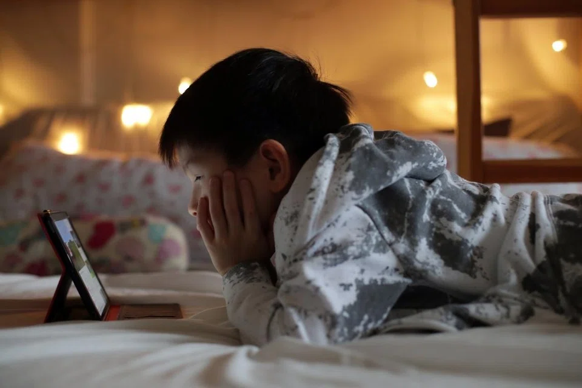

PHOTO: ST FILE

**Read:** [“S’pore studying restrictions on direct messaging, auto-play on social media to protect kids”](https://www.straitstimes.com/singapore/singapore-studying-restrictions-on-direct-messaging-auto-play-on-social-media)

**Canvas discussion board** · post one individual comment before **Mon, 23:59 SGT**

A recommender may be evaluated using whether people watch, click, or continue interacting with suggested content. What is **one responsibility** that evaluation should include for younger users, beyond predicting continued engagement?

In **120–160 words**, choose and name **one card-suit lens**, cite one article detail, and propose one piece of evidence, safeguard, or user control the platform should examine.

**No classmate reply this week.** Next week: protocols, ranking metrics, and what a score leaves out.

Next Week Preview — Week 03

Evaluation of Recommendation Systems

An offline metric tells us how a list performed. Next, we ask whether the recommendation process performs well under a scenario.

**In Week 3:**

- design an evaluation protocol;
- interpret ranked-list quality; and
- identify what a score does not capture.
- Bring the Week 01 four-suit lens **♣ ♥ ♦ ♠** into the picture.

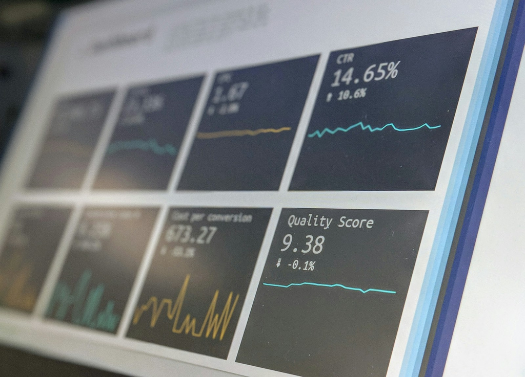

[Photo: Stephen Dawson / Unsplash](https://unsplash.com/photos/turned-on-monitoring-screen-qwtCeJ5cLYs)